# scratch gimap Genetic Interaction Review

2024-11-04

```r
library(tidyverse)
library(devtools)
library(magrittr)

devtools::load_all()
```

## Get the gimap GI results

```r
 gimap_dataset <- get_example_data("gimap") %>%
   gimap_filter() %>%
   gimap_annotate(cell_line = "HELA") %>%
   gimap_normalize(
     timepoints = "day") %>%
  calc_crispr() %>%
  calc_gi()
```

```
## Annotating Data
```

```
##
## Normalizing Log Fold Change
##
## Calculating CRISPR score
##
## Calculating Genetic Interaction scores
```

```r
saveRDS(gimap_dataset, "gimap_dataset_calculated.RDS")
```

## Load the GI Mapping GI results

```r
old_gi_results <- readRDS("d.HeLa_GI_scores_target")
```

#### sync the reps values

```r
old_gi_results %<>% mutate(
  rep = recode(rep, "A" = "Day22_RepA_late", "B" = "Day22_RepB_late", "C" = "Day22_RepC_late")
)
```

## Compare results

### Columns

```r
colnames(gimap_dataset$gi_scores)
```

```
## [1] "pgRNA_target_double"      "rep"
## [3] "double_target_gi_score"   "single_target_gi_score_1"
## [5] "single_target_gi_score_2" "expected_crispr_single_1"
## [7] "expected_crispr_single_2" "expected_crispr_double"
```

```r
colnames(old_gi_results)
```

```
##  [1] "rep"               "paralog_pair"      "target_type"
##  [4] "pgRNA_target"      "gene1_symbol"      "gene2_symbol"
##  [7] "intercept"         "slope"             "broad_target_type"
## [10] "p_val"             "fdr"               "mean_observed_CS"
## [13] "mean_expected_CS"  "mean_GI_score"
```

Looks like we want to compare the pgRNA targets which should be the `pgRNA_target_double` column for the gimap results and the `pgRNA_target` column for the GI Mapping results

Columns in the GI Mapping results not in the gimap results seem to include model results (`intercept`, `slope`) as well as some significance values (`p_val`, `fdr`), observed and expected CRISPR score (`mean_observed_CS` and `mean_expected_CS` (which I think I need for plotting)). And how does `mean_GI_score` relate to the three GI score columns in the gimap results? The three GI score columns relate to the different target types.

### Target overlap

```r
length(unique(gimap_dataset$normalized_log_fc$pgRNA_target))
```

```
## [1] 3091
```

```r
length(unique(old_gi_results$pgRNA_target))
```

```
## [1] 3086
```

```r
length(unique(gimap_dataset$gi_scores$pgRNA_target_double))
```

```
## [1] 1030
```

```r
length(intersect(unique(old_gi_results$pgRNA_target), unique(gimap_dataset$gi_scores$pgRNA_target_double)))
```

```
## [1] 1030
```

Only 1/3 of the GI Mapping targets are represented in the gimap results…

### Number of observations/rows total and rep column overlap

```r
nrow(old_gi_results)
```

```
## [1] 9258
```

```r
nrow(gimap_dataset$gi_scores)
```

```
## [1] 232596
```

The gimap results has far more rows…

```r
table(old_gi_results$rep)
```

```
##
## Day22_RepA_late Day22_RepB_late Day22_RepC_late
##            3086            3086            3086
```

```r
table(gimap_dataset$gi_scores$rep)
```

```
##
## Day05_RepA_early  Day22_RepA_late  Day22_RepB_late  Day22_RepC_late
##            58149            58149            58149            58149
```

While the replicate values themselves can’t be completely synced like we’ve done in other reviews due to the gimap results including the Day05_RepA_early datapoints, this further shows the far greater number of observations (even if there are fewer represented pgRNA targets) in the gimap results….

```r
head(old_gi_results)
```

```
## # A tibble: 6 × 14
##   rep            paralog_pair target_type pgRNA_target gene1_symbol gene2_symbol
##   <chr>          <chr>        <chr>       <chr>        <chr>        <chr>
## 1 Day22_RepA_la… AADAC_AADAC… gene_gene   AADAC_AADAC… AADAC        AADACL2
## 2 Day22_RepA_la… AADACL3_AAD… gene_gene   AADACL3_AAD… AADACL3      AADACL4
## 3 Day22_RepA_la… ABCC1_ABCC3  gene_gene   ABCC1_ABCC3  ABCC1        ABCC3
## 4 Day22_RepA_la… ABCC8_ABCC9  gene_gene   ABCC8_ABCC9  ABCC8        ABCC9
## 5 Day22_RepA_la… ABCD1_ABCD2  gene_gene   ABCD1_ABCD2  ABCD1        ABCD2
## 6 Day22_RepA_la… ABCG1_ABCG4  gene_gene   ABCG1_ABCG4  ABCG1        ABCG4
## # ℹ 8 more variables: intercept <dbl>, slope <dbl>, broad_target_type <chr>,
## #   p_val <dbl>, fdr <dbl>, mean_observed_CS <dbl>, mean_expected_CS <dbl>,
## #   mean_GI_score <dbl>
```

```r
joindf <- dplyr::full_join(old_gi_results, gimap_dataset$gi_scores,
                           by = c("pgRNA_target" = "pgRNA_target_double", "rep"),
                           suffix = c("_old", "_new"))
```

## Split out the comparisons we want to make

Have to drop NA’s because the gimap results include Day05_RepA_early datapoints while the GI Mapping doesn’t. Also have to drop NAs because there are GI Mapping targets that aren’t represented in the gimap targets?

```r
joined_df <- rbind(
  #join the gene_ctrl
  full_join(
    old_gi_results %>% filter(target_type == "gene_ctrl") %>% select(c("pgRNA_target", "paralog_pair", "mean_GI_score", "rep")),
    gimap_dataset$gi_scores %>% separate(pgRNA_target_double, c("gene1", "gene2"), sep="_", remove = FALSE) %>% mutate(ctrl = "ctrl") %>% unite("pgRNA_target_summary", c("gene1", "ctrl"), sep="_") %>% select(c("pgRNA_target_summary", "pgRNA_target_double", "single_target_gi_score_1", "rep")),
    by = c("pgRNA_target" = "pgRNA_target_summary", "paralog_pair"="pgRNA_target_double", "rep"),
    suffix = c("_old", "_new")
    ) %>% mutate(target_type = "gene_ctrl") %>% distinct() %>% select(c("pgRNA_target", "mean_GI_score", "rep", "single_target_gi_score_1", "target_type")) %>% `colnames<-`(c("pgRNA_target", "GI_Mapping_GI_score", "rep", "gimap_GI_score", "target_type")) %>% drop_na(),
  # join the ctrl_gene
  full_join(
    old_gi_results %>% filter(target_type == "ctrl_gene") %>% select(c("pgRNA_target", "paralog_pair", "mean_GI_score", "rep")),
    gimap_dataset$gi_scores %>% separate(pgRNA_target_double, c("gene1", "gene2"), sep="_", remove=FALSE) %>% mutate(ctrl = "ctrl") %>% unite("pgRNA_target_summary", c("ctrl", "gene2"), sep="_") %>% select(c("pgRNA_target_summary", "pgRNA_target_double", "single_target_gi_score_2", "rep")),
    by = c("pgRNA_target" = "pgRNA_target_summary", "rep"),
    suffix = c("_old", "_new")
    ) %>% mutate(target_type = "ctrl_gene") %>% distinct() %>% select(c("pgRNA_target", "mean_GI_score", "rep", "single_target_gi_score_2", "target_type")) %>% `colnames<-`(c("pgRNA_target", "GI_Mapping_GI_score", "rep", "gimap_GI_score", "target_type")) %>% drop_na(),
  #join the gene_gene
  full_join(
    old_gi_results %>% filter(target_type == "gene_gene") %>% select(c("pgRNA_target", "mean_GI_score", "rep")),
    gimap_dataset$gi_scores %>% select(c("pgRNA_target_double", "double_target_gi_score", "rep")),
    by = c("pgRNA_target" = "pgRNA_target_double", "rep"),
    suffix = c("_old", "_new")
  ) %>% mutate(target_type = "gene_gene") %>% `colnames<-`(c("pgRNA_target", "GI_Mapping_GI_score", "rep", "gimap_GI_score", "target_type")) %>% drop_na()
)
```

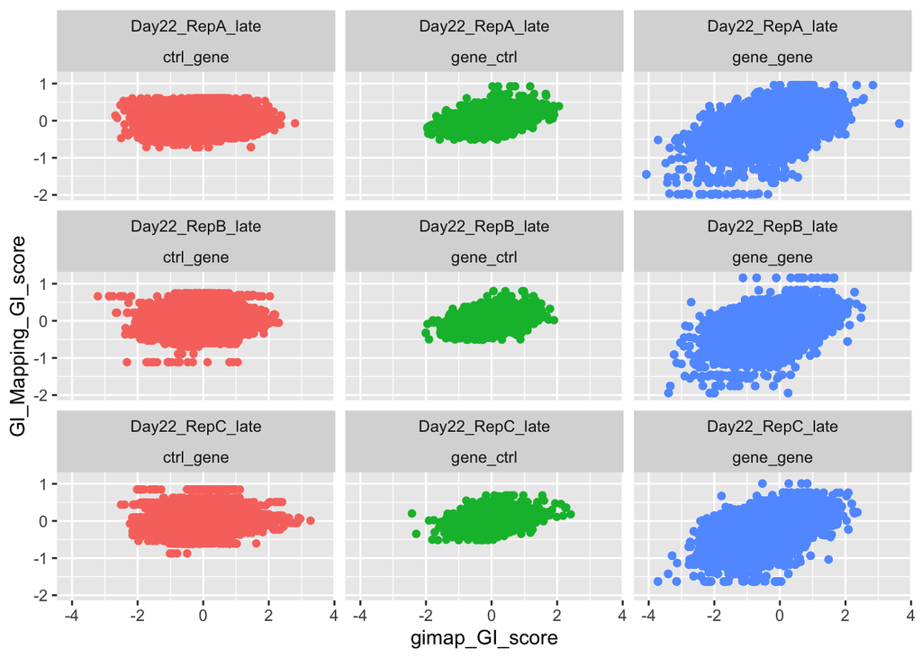

```r
joined_df %>% ggplot(aes(x=gimap_GI_score, y=GI_Mapping_GI_score, color=target_type)) + geom_point() + facet_wrap(rep~target_type) + theme(legend.position = "none")
```